# Módulo 1 — Fundação e Históricos de Detecção

Pipeline de análise de armadilhas fotográficas do Snapshot Brasil

**Como usar este caderno**

Este é um relatório **executável**, preparado para a reunião do grupo de trabalho do Snapshot Brasil. Leia o texto, execute cada bloco de código e observe o resultado logo abaixo. Começamos olhando de perto para o próprio Snapshot Brasil — sua estrutura de dados e o que suas câmeras de fato registraram — antes de apresentar as duas redes adicionais e o conjunto de dados combinado e pronto para análise, usado em todos os módulos seguintes.

# 1 O que este módulo faz

Este primeiro módulo estabelece a base para tudo o que segue. Ele responde a cinco perguntas antes que qualquer modelo seja ajustado:

1. **O que é o Snapshot Brasil, estruturalmente?** Como instalações, nomes de local (*placenames*) e sequências se tornam sítios e arrays, e como eram as próprias câmeras (tipo de armadilha, altura).
2. **O que de fato existe ali?** Um primeiro olhar sobre a própria comunidade de espécies do Snapshot Brasil — detecções e esforço amostral total — antes de qualquer outra rede ser adicionada.
3. **Como o registro de uma espécie se torna um histórico de detecção?** A entrada central que qualquer modelo de ocupação consome — uma matriz 0/1 de sítio por ocasião — apresentada aqui usando os próprios dados do Snapshot Brasil, antes de qualquer outra rede ser adicionada.
4. **Qual deve ser a duração de uma ocasião de amostragem?** Por que a ocupação usa janelas de detecção discretas, e o que muda ao alterar a janela — uma escolha que importa ainda mais quando redes com durações de instalação muito diferentes são combinadas.
5. **Que dados temos, uma vez combinados?** Duas redes adicionais de armadilhas fotográficas brasileiras, combinadas com o Snapshot Brasil em um único conjunto de dados pronto para análise — como foram selecionadas e combinadas, e como instalações brutas de câmera se tornam sítios e arrays nas três redes.

Restringimos todo este exercício a **mamíferos** (veja Seção 7.2 sobre o porquê).

# 2 Snapshot Brasil: estrutura e características

Antes de adicionar qualquer outra rede, vale entender o Snapshot Brasil em seus próprios termos. O Wildlife Insights (a plataforma sobre a qual o levantamento roda) organiza os dados de uma maneira específica, e essa estrutura permanece em tudo que segue:

- Uma **instalação** (*deployment*) é uma câmera funcionando continuamente em um **placename** por um período. Se uma câmera é reparada no meio da temporada (troca de bateria/cartão), isso gera uma segunda linha de instalação no mesmo placename — ainda uma única localização física de câmera.
- Uma **sequência** é uma rajada de fotos que o software da câmera agrupa como um único evento de disparo (ex.: um animal passando ao longo de alguns segundos). Cada sequência recebe uma identificação de espécie.
- Um **array** é a unidade básica de desenho amostral do Snapshot Brasil: um grupo de estações de câmera espacialmente agrupadas (uma “grade” ou “sítio” na terminologia do próprio levantamento) instaladas em conjunto para representar uma área amostrada.

```r
snap_dep <- fread(file.path(DATA, "snapshot_brasil_deployments.csv"))
snap_seq <- fread(file.path(DATA, "snapshot_brasil_sequences.csv"))
cat("instalações do Snapshot Brasil:", nrow(snap_dep),
    "| placenames distintos:", uniqueN(snap_dep$placename),
    "| arrays (subprojetos):", uniqueN(snap_dep$subproject_name), "\n")
```

```
#> instalações do Snapshot Brasil: 355 | placenames distintos: 349 | arrays (subprojetos): 24
```

```r
cat("total de câmeras-dia (instalações brutas):", sum(as.integer(as.Date(snap_dep$end_date) - as.Date(snap_dep$start_date)), na.rm=TRUE), "\n")
```

```
#> total de câmeras-dia (instalações brutas): 20727
```

```r
cat("total de sequências registradas:", nrow(snap_seq),
    "| sequências de mamíferos identificadas (excl. humanos):",
    nrow(snap_seq[class=="Mammalia" & genus!="Homo" & !is.na(genus) & !is.na(species)]), "\n")
```

```
#> total de sequências registradas: 14276 | sequências de mamíferos identificadas (excl. humanos): 9955
```

## 2.1 Tipo e altura da armadilha fotográfica

Cada instalação registra qual característica, se houver, estava próxima da câmera (`feature_type` — uma trilha, fonte de água, toca, ou um ponto aleatorizado sem característica específica próxima) e a que altura foi montada (`sensor_height`). O desenho amostral das câmeras é **aleatorizado** — os pontos de instalação não são escolhidos para buscar uma característica como um lago ou trilha — mas ainda é útil saber onde uma câmera por acaso caiu sobre uma delas, já que uma câmera perto de uma toca ou fonte de água amostra de forma diferente de uma em um ponto de grade aleatorizado, e a altura de uma câmera acima do solo restringe quais espécies e comportamentos ela pode capturar.

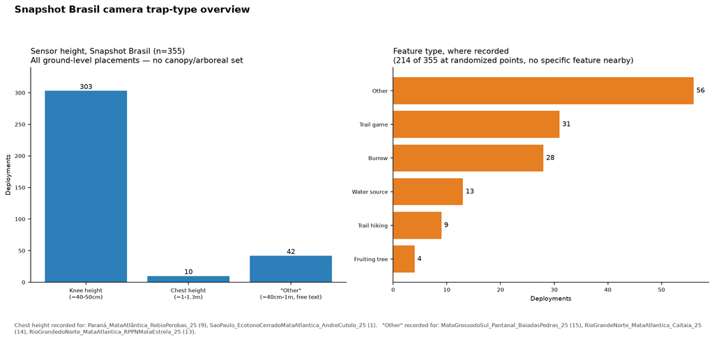

Visão geral do tipo de armadilha fotográfica do Snapshot Brasil. Esquerda: toda altura de sensor registrada é ao nível do solo — altura do joelho (~40-50cm, a grande maioria), altura do peito (~1-1,3m, registrada apenas para Paraná_MataAtlântica_RebioPerobas_25 e SaoPaulo_EcotonoCerradoMataAtlantica_AndreCutolo_25), ou ‘Outra’ (texto livre que se resolve em ~40cm ou ~1m acima do solo, registrada para MatoGrossodoSul_Pantanal_BaiadasPedras_25, RioGrandeNorte_MataAtlantica_Caitaia_25 e RioGrandedoNorte_MataAtlantica_RPPNMataEstrela_25). Não há conjunto de câmeras em dossel ou arbóreo neste levantamento. Direita: tipo de característica, onde registrado — a maioria das instalações (214 de 355) está em pontos de grade aleatorizados sem característica específica próxima; onde uma câmera caiu perto de uma característica, predominam trilhas, tocas e fontes de água.

```r
knitr::include_graphics(file.path(FIGS, "m1_camera_features.png"))
```

Verificamos especificamente um subconjunto de câmeras em altura de dossel, já que instalações arbóreas precisariam de tratamento separado no modelo de detecção (elas amostram uma comunidade diferente, e a suposição de “ativo” para um mamífero terrestre deixa de valer). Nenhum existe nos dados atuais — toda altura registrada é uma instalação ao nível do solo, então nenhuma exclusão é necessária por esse motivo.

# 3 Como é a própria comunidade do Snapshot Brasil

Antes de combinar qualquer coisa, eis o quadro de espécies do próprio Snapshot Brasil: quantas espécies, quantas detecções e quanto esforço amostral o levantamento representa por conta própria.

```r
snap_mammals <- snap_seq[class=="Mammalia" & genus!="Homo" & !is.na(genus) & !is.na(species)]
snap_mammals[, sci := paste(genus, species)]
cat("Táxons de mamíferos distintos registrados (gênero+espécie bruto, antes da harmonização taxonômica):",
    uniqueN(snap_mammals$sci), "\n")
```

```
#> Táxons de mamíferos distintos registrados (gênero+espécie bruto, antes da harmonização taxonômica): 108
```

```r
cat("Total de sequências de mamíferos identificadas:", nrow(snap_mammals), "\n")
```

```
#> Total de sequências de mamíferos identificadas: 9955
```

O mesmo quadro de taxa de detecção versus ocupação naive usado mais adiante para a comunidade completa combinada (Seção Seção 9) é mostrado aqui para o Snapshot Brasil por conta própria, usando suas próprias detecções independentes filtradas a 60 minutos e suas próprias câmeras-dia como denominador de esforço — antes de qualquer outra rede ser adicionada:

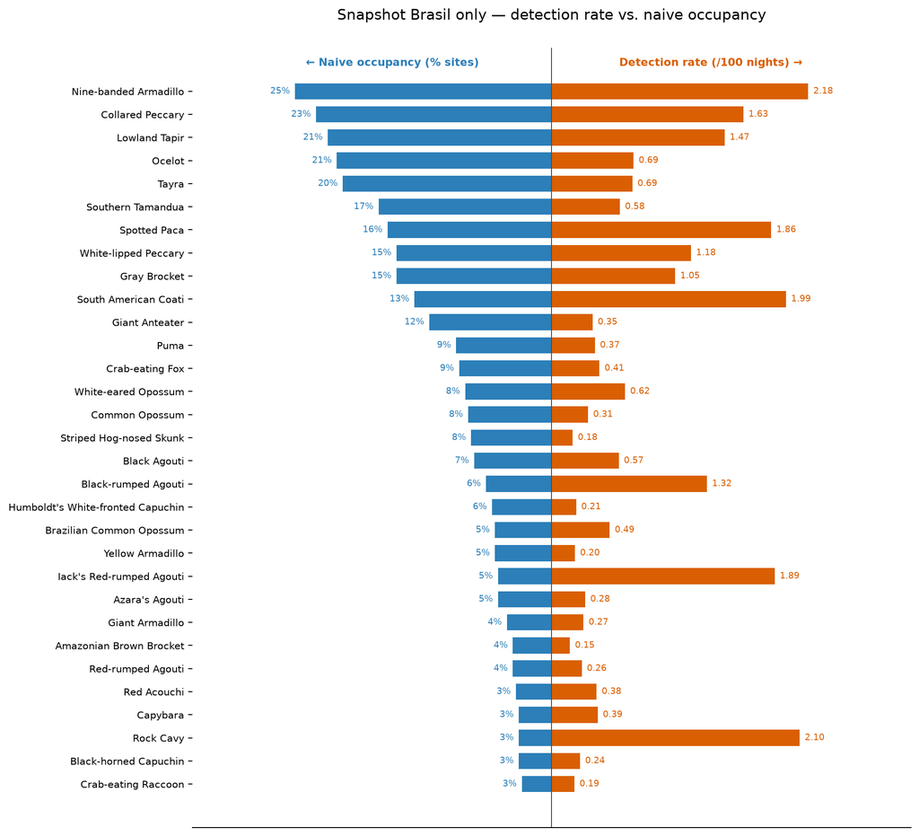

Somente Snapshot Brasil — taxa de detecção (direita, laranja) contra ocupação naive (esquerda, azul), para as 31 espécies de mamíferos que atingem o limiar de modelagem (≥30 detecções independentes e ≥8 sítios) dentro dos dados do próprio Snapshot Brasil, antes de as redes Atlântica e WI serem adicionadas. Compare com a Seção Seção 9 uma vez que a comunidade combinada completa seja construída.

```r
knitr::include_graphics(file.path(FIGS, "m1_xmas_ssbrazil_only.png"))
```

# 4 O intervalo de independência: de 1 minuto a 60 minutos

Todo conjunto de dados de armadilhas fotográficas precisa de uma regra para transformar um fluxo de fotos em “eventos de detecção” discretos e independentes — caso contrário, um animal que permanece diante da câmera (ou um grupo que passa junto) seria contado muitas vezes. A convenção usual é um limiar de **1 minuto**: duas fotos da mesma espécie na mesma câmera contam como uma detecção, a menos que mais de 1 minuto as separe.

Este pipeline usa em vez disso um limiar de **60 minutos**, para manter consistência com a compilação da Mata Atlântica (Seção Seção 7.1), cujos estudos-fonte não foram registrados com precisão suficiente para sustentar uma regra de 1 minuto. Ir de 1 minuto para 60 minutos não é gratuito: colapsa algumas detecções genuinamente independentes que por acaso caem dentro de uma hora uma da outra em um único evento. Podemos medir exatamente o que isso custa, usando os próprios registros de tempo de sequência do Snapshot Brasil (seus dados brutos têm registro de tempo, diferente das redes compiladas).

```r
overall <- fread(file.path(DATA, "m1_independence_interval_overall.csv"))
knitr::kable(overall, digits=1,
  col.names=c("Total de sequências","Independentes @ 1-min","Independentes @ 60-min","Detecções colapsadas","% colapsado"),
  caption="Snapshot Brasil, todas as sequências de mamíferos: efeito de mudar de um limiar de independência de 1 minuto para 60 minutos.")
```

Snapshot Brasil, todas as sequências de mamíferos: efeito de mudar de um limiar de independência de 1 minuto para 60 minutos.

| Total de sequências | Independentes @ 1-min | Independentes @ 60-min | Detecções colapsadas | % colapsado |
| --- | --- | --- | --- | --- |
| 8154 | 8151 | 5887 | 2264 | 27.8 |

No geral, **28%** das detecções que contariam como independentes no limiar convencional de 1 minuto são incorporadas a uma detecção anterior em 60 minutos. O efeito está longe de ser uniforme entre espécies:

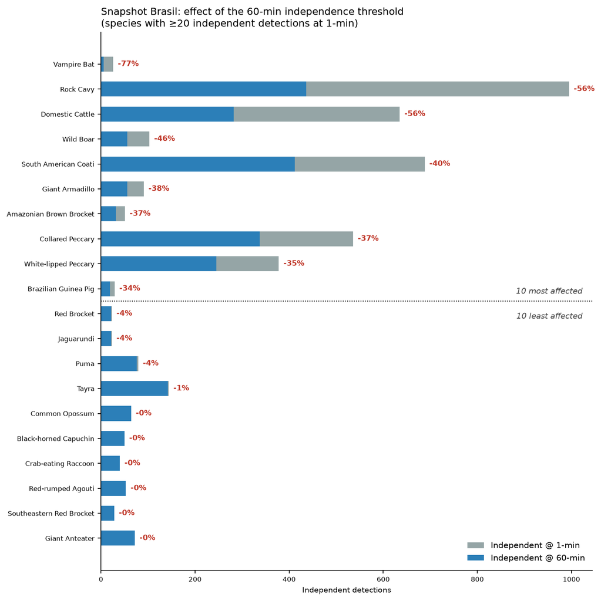

Espécies mais e menos afetadas pelo limiar de 60 minutos (entre espécies com pelo menos 20 detecções independentes a 1 minuto; as 10 mais afetadas aparecem acima da linha pontilhada, as 10 menos afetadas abaixo). O padrão é ecológico, não arbitrário: espécies gregárias ou que permanecem no local — mocó (colonial, associado a tocas), gado, quati (forrageia em bandos), queixadas (viajam em grupos) — perdem mais detecções, porque um grupo ou um animal que permanece dispara capturas repetidas dentro da mesma hora. Carnívoros solitários e de amplo deslocamento (jaguarundi, onça-parda, irara) e várias espécies com perda praticamente nula ficam na outra ponta da escala.

```r
knitr::include_graphics(file.path(FIGS, "m1_independence_interval_collapse.png"))
```

A conclusão prática: o limiar de 60 minutos é uma troca real e quantificável — custa mais para espécies gregárias e que permanecem no local, e comparativamente pouco para espécies solitárias. Adotá-lo por consistência entre redes é uma escolha defensável, mas taxas de detecção para espécies altamente sociais devem ser lidas como um pouco mais conservadoras do que uma convenção de 1 minuto daria.

# 5 Históricos de detecção

Modelos de ocupação não usam fotos brutas. Eles usam um **histórico de detecção**: para cada sítio, o período de amostragem é dividido em **ocasiões** iguais (aqui, janelas de 7 dias), e cada ocasião é marcada **1** (espécie detectada ao menos uma vez) ou **0** (não detectada mas a câmera estava ativa). Essa sequência 1/0/1/1/0… é a matéria-prima de um modelo de ocupação.

Usamos a **cutia-preta** no array de Tefé (Amazonas) como exemplo: uma única temporada contínua de 2025 com 30 câmeras e sem lacunas de manutenção, então o quadro é direto de ler.

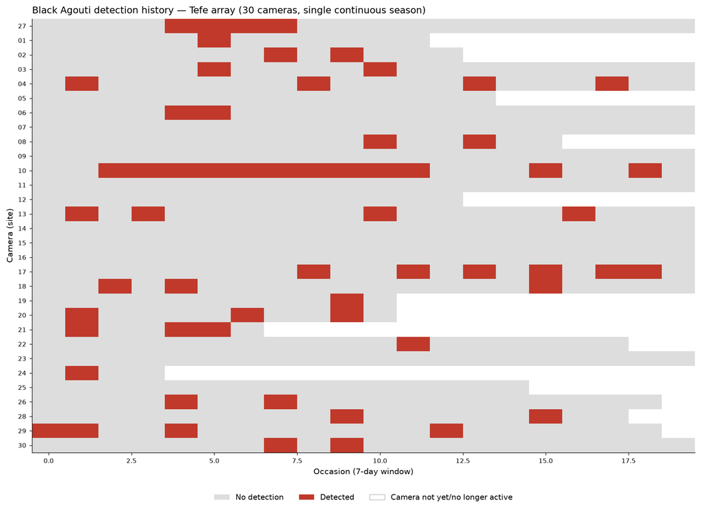

Histórico de detecção da cutia-preta no array de Tefé (30 câmeras, temporada única contínua). Cinza = câmera ativa, sem detecção; vermelho = detectado naquela ocasião de 7 dias; branco = câmera ainda não ativa ou não mais ativa. Vinte de trinta câmeras detectaram a espécie ao menos uma vez; uma câmera (linha 10) mostra uma sequência incomumente longa de detecções consecutivas, um sinal comportamental real (um indivíduo residente usando aquele local repetidamente), não um artefato de dados.

```r
knitr::include_graphics(file.path(FIGS, "m1_dethist_new_example.png"))
```

A matriz literal 0/1 por trás da figura — a entrada real que um modelo de ocupação consome — se parece com isto (primeiras 15 de 20 ocasiões, todas as 30 câmeras; células em branco significam que a câmera ainda não estava ativa ou não estava mais ativa):

```r
dh_tbl <- fread(file.path(DATA, "m1_dethist_table.csv"), colClasses="character")
knitr::kable(dh_tbl, caption="Histórico de detecção 0/1 da cutia-preta, array de Tefé, primeiras 15 ocasiões.")
```

Histórico de detecção 0/1 da cutia-preta, array de Tefé, primeiras 15 ocasiões.

| camera | occ1 | occ2 | occ3 | occ4 | occ5 | occ6 | occ7 | occ8 | occ9 | occ10 | occ11 | occ12 | occ13 | occ14 | occ15 |
| --- | --- | --- | --- | --- | --- | --- | --- | --- | --- | --- | --- | --- | --- | --- | --- |
| 27 | 0 | 0 | 0 | 0 | 1 | 1 | 1 | 1 | 0 | 0 | 0 | 0 | 0 | 0 | 0 |
| 01 | 0 | 0 | 0 | 0 | 0 | 1 | 0 | 0 | 0 | 0 | 0 | 0 |  |  |  |
| 02 | 0 | 0 | 0 | 0 | 0 | 0 | 0 | 1 | 0 | 1 | 0 | 0 | 0 |  |  |
| 03 | 0 | 0 | 0 | 0 | 0 | 1 | 0 | 0 | 0 | 0 | 1 | 0 | 0 | 0 | 0 |
| 04 | 0 | 1 | 0 | 0 | 0 | 0 | 0 | 0 | 1 | 0 | 0 | 0 | 0 | 1 | 0 |
| 05 | 0 | 0 | 0 | 0 | 0 | 0 | 0 | 0 | 0 | 0 | 0 | 0 | 0 | 0 |  |
| 06 | 0 | 0 | 0 | 0 | 1 | 1 | 0 | 0 | 0 | 0 | 0 | 0 | 0 | 0 | 0 |
| 07 | 0 | 0 | 0 | 0 | 0 | 0 | 0 | 0 | 0 | 0 | 0 | 0 | 0 | 0 | 0 |
| 08 | 0 | 0 | 0 | 0 | 0 | 0 | 0 | 0 | 0 | 0 | 1 | 0 | 0 | 1 | 0 |
| 09 | 0 | 0 | 0 | 0 | 0 | 0 | 0 | 0 | 0 | 0 | 0 | 0 | 0 | 0 | 0 |
| 10 | 0 | 0 | 1 | 1 | 1 | 1 | 1 | 1 | 1 | 1 | 1 | 1 | 0 | 0 | 0 |
| 11 | 0 | 0 | 0 | 0 | 0 | 0 | 0 | 0 | 0 | 0 | 0 | 0 | 0 | 0 | 0 |
| 12 | 0 | 0 | 0 | 0 | 0 | 0 | 0 | 0 | 0 | 0 | 0 | 0 | 0 |  |  |
| 13 | 0 | 1 | 0 | 1 | 0 | 0 | 0 | 0 | 0 | 0 | 1 | 0 | 0 | 0 | 0 |
| 14 | 0 | 0 | 0 | 0 | 0 | 0 | 0 | 0 | 0 | 0 | 0 | 0 | 0 | 0 | 0 |
| 15 | 0 | 0 | 0 | 0 | 0 | 0 | 0 | 0 | 0 | 0 | 0 | 0 | 0 | 0 | 0 |
| 16 | 0 | 0 | 0 | 0 | 0 | 0 | 0 | 0 | 0 | 0 | 0 | 0 | 0 | 0 | 0 |
| 17 | 0 | 0 | 0 | 0 | 0 | 0 | 0 | 0 | 1 | 0 | 0 | 1 | 0 | 1 | 0 |
| 18 | 0 | 0 | 1 | 0 | 1 | 0 | 0 | 0 | 0 | 0 | 0 | 0 | 0 | 0 | 0 |
| 19 | 0 | 0 | 0 | 0 | 0 | 0 | 0 | 0 | 0 | 1 | 0 |  |  |  |  |
| 20 | 0 | 1 | 0 | 0 | 0 | 0 | 1 | 0 | 0 | 1 | 0 |  |  |  |  |
| 21 | 0 | 1 | 0 | 0 | 1 | 1 | 0 |  |  |  |  |  |  |  |  |
| 22 | 0 | 0 | 0 | 0 | 0 | 0 | 0 | 0 | 0 | 0 | 0 | 1 | 0 | 0 | 0 |
| 23 | 0 | 0 | 0 | 0 | 0 | 0 | 0 | 0 | 0 | 0 | 0 | 0 | 0 | 0 | 0 |
| 24 | 0 | 1 | 0 | 0 |  |  |  |  |  |  |  |  |  |  |  |
| 25 | 0 | 0 | 0 | 0 | 0 | 0 | 0 | 0 | 0 | 0 | 0 | 0 | 0 | 0 | 0 |
| 26 | 0 | 0 | 0 | 0 | 1 | 0 | 0 | 1 | 0 | 0 | 0 | 0 | 0 | 0 | 0 |
| 28 | 0 | 0 | 0 | 0 | 0 | 0 | 0 | 0 | 0 | 1 | 0 | 0 | 0 | 0 | 0 |
| 29 | 1 | 1 | 0 | 0 | 1 | 0 | 0 | 0 | 0 | 0 | 0 | 0 | 1 | 0 | 0 |
| 30 | 0 | 0 | 0 | 0 | 0 | 0 | 0 | 1 | 0 | 1 | 0 | 0 | 0 | 0 | 0 |

# 6 Escolhendo a janela de ocasião

## 6.1 Por que a duração da janela importa

A duração da ocasião é uma escolha de modelagem, não uma propriedade dos dados. Ela equilibra duas coisas:

- **Curta demais** (ex.: 1 dia): a maioria das ocasiões é 0 simplesmente porque o animal não estava ali *naquele dia*, mesmo que use o sítio. A probabilidade de detecção por ocasião é muito baixa e a ocupação é subestimada.
- **Longa demais** (ex.: 30 dias): quase toda ocasião se torna 1 para espécies comuns, e o modelo perde a informação que distingue sítios, e instalações curtas produzem poucas ocasiões para sequer estimar a detecção.

Espécies diferentes podem justificar janelas diferentes — um carnívoro de amplo deslocamento e baixa densidade que visita um sítio a cada poucas semanas precisa de uma janela mais longa do que um roedor residente fotografado toda noite. Em um pipeline multiespécies, porém, uma única janela comum mantém toda espécie em pé de igualdade e todo array comparável.

## 6.2 Por que 7 dias

Adotamos uma **janela de ocasião de 7 dias** como padrão do pipeline. É curta o suficiente para que espécies comuns ainda variem entre ocasiões (as ocasiões não são todas 1), e longa o suficiente para que mesmo instalações curtas ainda produzam várias ocasiões — uma propriedade que se torna essencial quando combinamos três redes com durações de instalação muito diferentes na próxima seção. Janelas mais largas reduziriam ainda mais a correlação entre ocasiões adjacentes, mas custariam ocasiões demais para câmeras instaladas brevemente, uma troca que este conjunto de dados multi-rede não pode se dar ao luxo de fazer.

# 7 Combinando três redes em um único conjunto de dados

A análise completa combina três fontes de dados de armadilhas fotográficas brasileiras, todas em formato Wildlife Insights:

| Rede | O que é | Anos | Seleção |
| --- | --- | --- | --- |
| **Snapshot Brasil** | O levantamento nacional coordenado de 2025 (Seção Seção 2) | 2025 | Temporada única; usado como está |
| **Mata Atlântica** | Uma compilação de estudos da Mata Atlântica | 2016–2020 | Filtrado e agrupado (abaixo) |
| **Projetos públicos WI** | Projetos públicos do Wildlife Insights no Brasil | 2010–2025 | Filtrado e agrupado (abaixo) |

```r
dep <- fread(file.path(DATA, "final_deployments.csv"))
det <- fread(file.path(DATA, "detections.csv"))   # apenas mamíferos
cat("redes:", uniqueN(dep$network),
    "| arrays:", uniqueN(dep$array_id),
    "| sítios:", uniqueN(dep$site_id),
    "| instalações:", nrow(dep),
    "| câmeras-dia:", format(sum(dep$camera_days, na.rm=TRUE), big.mark=","), "\n")
```

```
#> redes: 3 | arrays: 61 | sítios: 1107 | instalações: 1205 | câmeras-dia: 66,880
```

```r
cat("detecções de mamíferos:", format(nrow(det), big.mark=","),
    "| espécies de mamíferos (todas as identificações):", uniqueN(det$sci_mdd), "\n")
```

```
#> detecções de mamíferos: 24,135 | espécies de mamíferos (todas as identificações): 148
```

## 7.1 Como os dados da Mata Atlântica e WI foram selecionados

O Snapshot Brasil é um levantamento propositalmente construído com um desenho consistente. As outras duas redes são compilações de estudos independentes, então precisaram de harmonização ao mesmo padrão antes de poderem ser combinadas. As mesmas regras foram aplicadas a ambas:

- **Excluir câmeras com isca** (apenas Mata Atlântica — alguns estudos usaram isca, o que muda as taxas de detecção e quebra a comparabilidade).
- **Intervalo de independência — 60 minutos em todas as redes** (veja a Seção Seção 4 acima para o que isso custa, medido nos próprios dados do Snapshot Brasil).
- **Agrupar câmeras em arrays** usando a regra de desenho do Snapshot: câmeras a menos de **200 m** são reduzidas a uma, câmeras são ligadas em um array se estiverem a menos de **5 km** de uma vizinha, e um array só é mantido se tiver **≥ 10 câmeras**. Isso faz um “array” significar a mesma coisa em cada rede — um agrupamento espacialmente compacto de câmeras, a unidade de replicação para análises comunitárias.
- **Uma temporada por array** — para as redes multi-anuais Mata Atlântica e WI, cada array é fixado em seu único ano mais bem amostrado, de modo que um array represente uma temporada fechada. O Snapshot já é uma temporada única e está isento.
- **Precisão de coordenadas** — oito sítios com coordenadas arredondadas a ~1 km foram removidos, porque suas covariáveis ambientais (amostradas em buffers de 100 m) estariam erradas.

O resultado é um conjunto de dados onde um “sítio” e um “array” carregam o mesmo significado independentemente de qual rede a câmera veio.

## 7.2 Uma escolha de consistência: apenas mamíferos

A compilação da Mata Atlântica registrou **apenas mamíferos**. Se mantivéssemos aves na análise, toda ave apareceria falsamente *ausente* em todos os arrays da Mata Atlântica — não porque as aves estejam ausentes ali, mas porque essa rede nunca as registrou. Isso é um artefato de dados, não ecologia. Para manter toda espécie comparável entre as três redes, restringimos a análise inteira a **mamíferos**. (Os registros de aves do Snapshot são deixados de lado para este exercício; o WI não registrou aves.)

## 7.3 Taxonomia: harmonizando nomes entre redes

As três redes foram compiladas em épocas diferentes e usam nomes taxonômicos diferentes para os mesmos animais. Reconciliamos todo nome ao **Mammal Diversity Database (MDD) v2.4**, o padrão global atual, de modo que (por exemplo) *Mazama gouazoubira* e *Subulo gouazoubira* sejam reconhecidos como o mesmo veado-catingueiro. A tabela abaixo lista todo nome que atualizamos. Dois são sinalizados como ambíguos (a sinonímia admite mais de uma interpretação moderna); adotamos a leitura aceita do mesmo gênero e a anotamos.

```r
tax <- fread(file.path(DATA, "taxonomy_changes.csv"))
tax_disp <- tax[, .(nome_dados = data_name, mdd_aceito = mdd_accepted,
                     nome_comum = mdd_common,
                     ambiguo = ifelse(ambiguous, "sim", ""),
                     fontes = sources)]
knitr::kable(
  tax_disp,
  col.names = c("Nome nos dados", "Aceito pelo MDD v2.4", "Nome comum", "Ambíguo", "Fontes"),
  caption = "Atualizações de nomes taxonômicos aplicadas ao conjunto de dados combinado (MDD v2.4)."
)
```

Atualizações de nomes taxonômicos aplicadas ao conjunto de dados combinado (MDD v2.4).

| Nome nos dados | Aceito pelo MDD v2.4 | Nome comum | Ambíguo | Fontes |
| --- | --- | --- | --- | --- |
| Dasyprocta aguti | Dasyprocta leporina | Common Red-rumped Agouti |  | Atlantic |
| Leontocebus fuscicollis | Saguinus fuscicollis | Spix’s Saddle-back Tamarin |  | WI |
| Leopardus colocolo | Leopardus colocola | Central Chilean Colocolo |  | WI |
| Lycalopex gymnocercus | Lycalopex gymnocerca | Pampas Fox |  | Atlantic |
| Lycalopex vetulus | Lycalopex vetula | Hoary Fox | sim | Atlantic+WI |
| Mazama gouazoubira | Subulo gouazoubira | Southern Brown Brocket |  | Atlantic+RangeMap |
| Mazama nana | Mazama nanus | Pygmy Red Brocket | sim | Atlantic |
| Mazama nemorivaga | Passalites nemorivagus | Northern Brown Brocket |  | WI |
| Pecari tajacu | Dicotyles tajacu | Collared Peccary |  | RangeMap |
| Saguinus melanoleucus | Saguinus weddellii | Weddell’s Saddle-back Tamarin |  | WI |
| Saguinus weddelli | Saguinus weddellii | Weddell’s Saddle-back Tamarin |  | WI |

## 7.4 Onde estão as câmeras, e quando

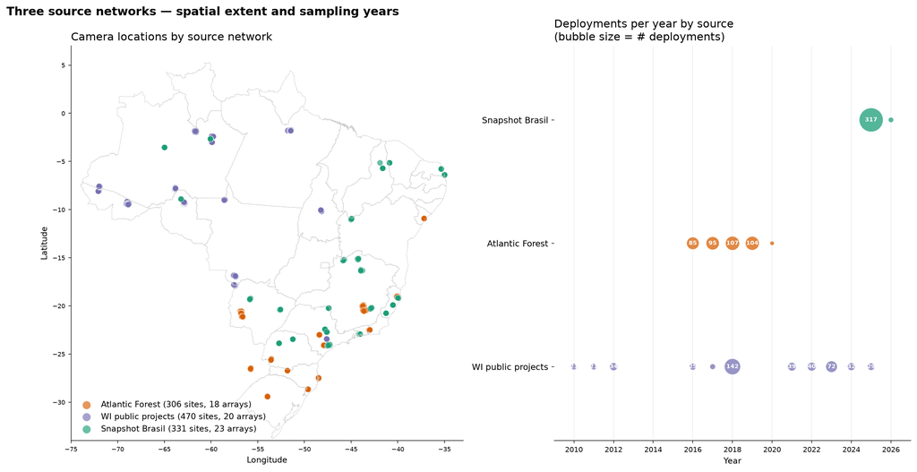

As três redes-fonte. Esquerda: localizações das câmeras, coloridas por rede. Direita: instalações por ano — Snapshot é um pulso único de 2025, Mata Atlântica se concentra em 2016–2019, e WI se estende de 2010 a 2025. As redes juntas cobrem um amplo gradiente latitudinal e de biomas pelo Brasil.

```r
knitr::include_graphics(file.path(FIGS, "m1_three_source_map.png"))
```

# 8 De instalações a sítios, arrays e esforço

Fazer isso corretamente importa porque o **array** — não a câmera individual — é a unidade de replicação que todo modelo posterior usa para efeitos aleatórios e comparações comunitárias. Um array que contivesse silenciosamente sítios duplicados ou inflados por lacunas enviesaria toda estimativa de ocupação e abundância construída sobre ele, de formas muito difíceis de detectar depois do fato.

```r
eff <- dep[, .(camera_days = sum(camera_days, na.rm=TRUE),
               n_deploy = .N), by = .(network, array_id, site_id)]
cat("sítios distintos:", uniqueN(eff$site_id),
    "| câmeras-dia mediana por sítio:", round(median(eff$camera_days, na.rm=TRUE)), "\n")
```

```
#> sítios distintos: 1107 | câmeras-dia mediana por sítio: 47
```

```r
cat("esforço por rede (câmeras-dia):\n")
```

```
#> esforço por rede (câmeras-dia):
```

```r
print(eff[, .(sitios=uniqueN(site_id), camera_days=sum(camera_days)), by=network])
```

```
#>     network sitios camera_days
#>      <char>  <int>       <int>
#> 1: Atlantic    306       20941
#> 2:       WI    470       26352
#> 3: Snapshot    331       19587
```

# 9 Como é a comunidade

Por fim, um primeiro olhar sobre a comunidade de mamíferos nas três redes combinadas — antes de qualquer modelo. Para cada espécie calculamos dois resumos simples:

- **Taxa de detecção** — detecções por 100 câmeras-noite (sinal bruto).
- **Ocupação ingênua** — a porcentagem de sítios onde a espécie foi detectada ao menos uma vez (não corrigida para detecção imperfeita).

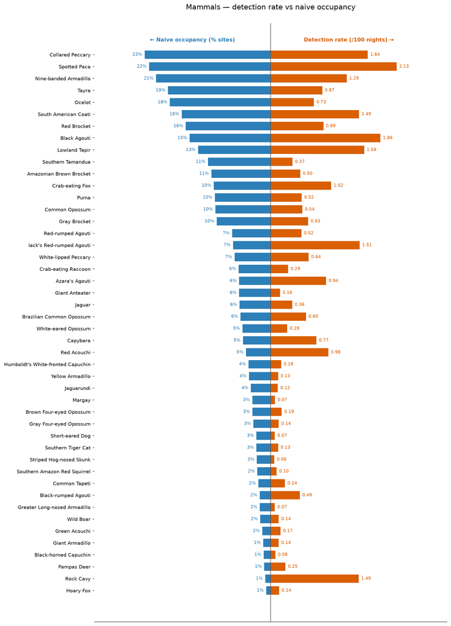

Comunidade de mamíferos — taxa de detecção (direita, laranja) contra ocupação ingênua (esquerda, azul), para as espécies com dados suficientes para modelar (≥30 detecções e ≥8 sítios). Os dois lados podem discordar: uma espécie pode ser amplamente distribuída mas raramente fotografada (ex.: jaguatirica), ou localmente abundante mas geograficamente restrita (ex.: mocó). Essa distância é exatamente o que os modelos de ocupação e abundância são construídos para resolver — a ocupação ingênua sempre subestima a ocupação verdadeira, porque uma espécie pode estar presente mas não detectada em nenhuma visita; corrigir isso é o trabalho do Módulo 3.

```r
knitr::include_graphics(file.path(FIGS, "m1_xmas_mammals.png"))
```

O conjunto modelado é composto pelas **46 espécies de mamíferos** que atingem o limiar de dados — a comunidade de trabalho para os módulos de ocupação, comunidade e interação que seguem.

# 10 O que os resultados significam

- Agora temos um quadro claro do Snapshot Brasil em seus próprios termos — sua estrutura (instalações, placenames, sequências, arrays) e o tipo/altura de suas armadilhas fotográficas, todas instalações padrão ao nível do solo, sem conjunto em dossel a excluir.
- O limiar de independência de 60 minutos, adotado por consistência com a rede da Mata Atlântica, tem um custo real e mensurável concentrado em espécies gregárias e que permanecem no local — uma troca que vale a pena conhecer, não uma suposição oculta.
- Temos um único conjunto de dados harmonizado e **apenas de mamíferos**, oriundo de três redes, abrangendo um amplo gradiente ambiental pelo Brasil.
- As unidades analíticas — sítios, arrays, históricos de detecção — significam a mesma coisa nas três fontes, o que é o que torna uma análise combinada defensável; acertar a etapa de instalação-para-sítio (respeitando janelas reais de câmera ativa, não o intervalo total entre visitas de manutenção) importa porque todo modelo posterior trata o array como sua unidade de replicação.
- Uma **janela de ocasião de 7 dias** é o padrão do pipeline, escolhida para equilibrar informação contra as instalações curtas nos dados combinados.